# Practical Machine Learning Course Project Report

Harmeet

August 01, 2016

### Laoding the libraries etc

```r
setwd("C:/Users/Shaffu_Knowledge/Desktop")

library(caret)
library(randomForest)
```

```r
library(rpart.plot)
```

## Data Sources

### https://d396qusza40orc.cloudfront.net/predmachlearn/pml-training.csv

### https://d396qusza40orc.cloudfront.net/predmachlearn/pml-testing.csv

## Data Info

### We clean the data while loading the data from the csv files for training and validation.

### Quick look at the data, Note the classe is being predicted here

```r
train_data  <- read.csv("pml-training.csv", na.strings = c("NA", "#DIV/0!", ""))
valid_data  <- read.csv("pml-testing.csv",  na.strings = c("NA", "#DIV/0!", ""))

str(train_data, list.len=15)
```

```
## 'data.frame':    19622 obs. of  160 variables:
##  $ X                       : int  1 2 3 4 5 6 7 8 9 10 ...
##  $ user_name               : Factor w/ 6 levels "adelmo","carlitos",..: 2 2 2 2 2 2 2 2 2 2 ...
##  $ raw_timestamp_part_1    : int  1323084231 1323084231 1323084231 1323084232 1323084232 1323084232 1323084232 1323084232 1323084232 1323084232 ...
##  $ raw_timestamp_part_2    : int  788290 808298 820366 120339 196328 304277 368296 440390 484323 484434 ...
##  $ cvtd_timestamp          : Factor w/ 20 levels "02/12/2011 13:32",..: 9 9 9 9 9 9 9 9 9 9 ...
##  $ new_window              : Factor w/ 2 levels "no","yes": 1 1 1 1 1 1 1 1 1 1 ...
##  $ num_window              : int  11 11 11 12 12 12 12 12 12 12 ...
##  $ roll_belt               : num  1.41 1.41 1.42 1.48 1.48 1.45 1.42 1.42 1.43 1.45 ...
##  $ pitch_belt              : num  8.07 8.07 8.07 8.05 8.07 8.06 8.09 8.13 8.16 8.17 ...
##  $ yaw_belt                : num  -94.4 -94.4 -94.4 -94.4 -94.4 -94.4 -94.4 -94.4 -94.4 -94.4 ...
##  $ total_accel_belt        : int  3 3 3 3 3 3 3 3 3 3 ...
##  $ kurtosis_roll_belt      : num  NA NA NA NA NA NA NA NA NA NA ...
##  $ kurtosis_picth_belt     : num  NA NA NA NA NA NA NA NA NA NA ...
##  $ kurtosis_yaw_belt       : logi  NA NA NA NA NA NA ...
##  $ skewness_roll_belt      : num  NA NA NA NA NA NA NA NA NA NA ...
##   [list output truncated]
```

```r
table(train_data$classe)
```

```
##
##    A    B    C    D    E
## 5580 3797 3422 3216 3607
```

```r
prop.table(table(train_data$user_name, train_data$classe), 1)
```

```
##
##                    A         B         C         D         E
##   adelmo   0.2993320 0.1993834 0.1927030 0.1323227 0.1762590
##   carlitos 0.2679949 0.2217224 0.1584190 0.1561697 0.1956941
##   charles  0.2542421 0.2106900 0.1524321 0.1815611 0.2010747
##   eurico   0.2817590 0.1928339 0.1592834 0.1895765 0.1765472
##   jeremy   0.3459730 0.1437390 0.1916520 0.1534392 0.1651969
##   pedro    0.2452107 0.1934866 0.1911877 0.1796935 0.1904215
```

```r
prop.table(table(train_data$classe))
```

```
##
##         A         B         C         D         E
## 0.2843747 0.1935073 0.1743961 0.1638977 0.1838243
```

## Cross Validation

### Dropping first 6 columns which are information based.

### Partitioning the data into Training and Validation into 60% and 40% data sets

### Identify the zero covariates and remove them from train_1 and train_2

```r
train_data <- train_data[, 7:160]
valid_data  <- valid_data[, 7:160]

data  <- apply(!is.na(train_data), 2, sum) > 19621
train_data <- train_data[, data]
valid_data  <- valid_data[, data]


set.seed(99)
in_train <- createDataPartition(y=train_data$classe, p=0.60, list=FALSE)
train_1  <- train_data[in_train,]
train_2  <- train_data[-in_train,]
dim(train_1)
```

```
## [1] 11776    54
```

```r
dim(train_2)
```

```
## [1] 7846   54
```

```r
nzv_cols <- nearZeroVar(train_1)
if(length(nzv_cols) > 0) {
  train_1 <- train_1[, -nzv_cols]
  train_2 <- train_2[, -nzv_cols]
}

dim(train_1)
```

```
## [1] 11776    54
```

```r
dim(train_2)
```

```
## [1] 7846   54
```

### There are 53 Covariates Identified. Their relative importance is checked using the random forest and plotting the data

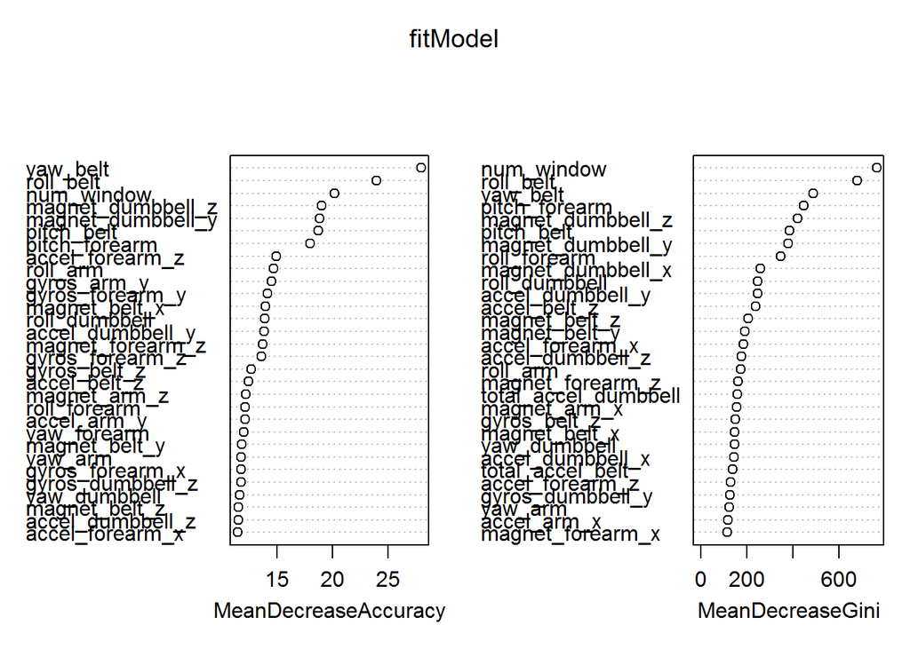

```r
set.seed(99)
fitModel <- randomForest( classe~., data=train_1, importance=TRUE, ntree=100)
varImpPlot(fitModel)
```

### We will use accuracy and gini graphs to use the top 10 relavent varaibles.They being: yaw_belt, roll_belt, num_window, pitch_belt, magnet_dumbbell_y, magnet_dumbbell_z, pitch_forearm, accel_dumbbell_y, roll_arm, and roll_forearm.

### Correltion matrix for 10 varibales if the value is greater than 75%

```r
cor_rel = cor(train_1[,c("yaw_belt","roll_belt","num_window","pitch_belt","magnet_dumbbell_z",
                        "magnet_dumbbell_y","pitch_forearm","accel_dumbbell_y","roll_arm",
                        "roll_forearm")])
diag(cor_rel) <- 0
which(abs(cor_rel)>0.75, arr.ind=TRUE)
```

```
##           row col
## roll_belt   2   1
## yaw_belt    1   2
```

```r
cor(train_1$roll_belt, train_1$yaw_belt)
```

```
## [1] 0.8133561
```

### roll_belt and yaw_belt which have a high correlation greater than 75%. Dropping yaw_belt

```r
cor_rel = cor(train_1[,c("roll_belt","num_window","pitch_belt","magnet_dumbbell_z",
                        "magnet_dumbbell_y","pitch_forearm","accel_dumbbell_y","roll_arm",
                        "roll_forearm")])
diag(cor_rel) <- 0
which(abs(cor_rel)>0.50, arr.ind=TRUE)
```

```
##                   row col
## magnet_dumbbell_z   4   1
## roll_belt           1   4
```

### Now we see there is correlation of 50% and we retain these

### We categorize the data into groups based on roll_belt values and run tree classifier

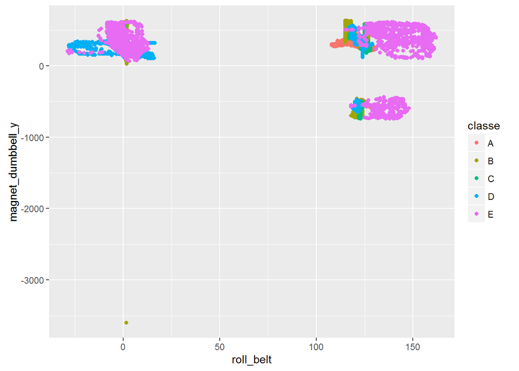

```r
qplot(roll_belt, magnet_dumbbell_y, colour=classe, data=train_1)
```

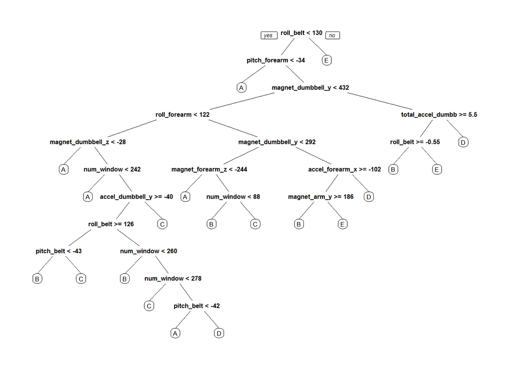

```r
fitModel <- rpart(classe~., data=train_1, method="class")
prp(fitModel)
```

### Running Modeling with random forest, saving the result in a file. ### Building Confusion Matrix on train data 2 - train_2.

```r
set.seed(99)
fitModel <- train(classe ~ roll_belt +  num_window + pitch_belt  + magnet_dumbbell_y +
                           magnet_dumbbell_z + pitch_forearm + accel_dumbbell_y +
                           roll_arm + roll_forearm,
                  data=train_1,method="rf",
                  trControl=trainControl(method="cv",number=2),
                  prox=TRUE,verbose=TRUE,
                  allowParallel=TRUE)


saveRDS(fitModel, "RF_model.Rds")
fitModel <- readRDS("RF_model.Rds")


predictions <- predict(fitModel, newdata=train_2)
confusionMat <- confusionMatrix(predictions, train_2$classe)
confusionMat
```

```
## Confusion Matrix and Statistics
##
##           Reference
## Prediction    A    B    C    D    E
##          A 2231    3    0    0    0
##          B    1 1513    2    0    2
##          C    0    2 1366   14    0
##          D    0    0    0 1270    0
##          E    0    0    0    2 1440
##
## Overall Statistics
##
##                Accuracy : 0.9967
##                  95% CI : (0.9951, 0.9978)
##     No Information Rate : 0.2845
##     P-Value [Acc > NIR] : < 2.2e-16
##
##                   Kappa : 0.9958
##  Mcnemar's Test P-Value : NA
##
## Statistics by Class:
##
##                      Class: A Class: B Class: C Class: D Class: E
## Sensitivity            0.9996   0.9967   0.9985   0.9876   0.9986
## Specificity            0.9995   0.9992   0.9975   1.0000   0.9997
## Pos Pred Value         0.9987   0.9967   0.9884   1.0000   0.9986
## Neg Pred Value         0.9998   0.9992   0.9997   0.9976   0.9997
## Prevalence             0.2845   0.1935   0.1744   0.1639   0.1838
## Detection Rate         0.2843   0.1928   0.1741   0.1619   0.1835
## Detection Prevalence   0.2847   0.1935   0.1761   0.1619   0.1838
## Balanced Accuracy      0.9995   0.9980   0.9980   0.9938   0.9992
```

### out-of-sample error rate

```r
miss_classification = function(values, predicted) {
  sum(predicted != values) / length(values)
}
oos_err_rate = miss_classification(train_2$classe, predictions)
oos_err_rate
```

```
## [1] 0.00331379
```

### The 20 Questions to be answered - output in a file

```r
predictions <- predict(fitModel, newdata=valid_data)
valid_data$classe <- predictions
submit <- data.frame(problem_id = valid_data$problem_id, classe = predictions)
write.csv(submit, file = "coursera_sub.csv", row.names = FALSE)
ans = valid_data$classe
write_files = function(x){
  n = length(x)
  for(i in 1:n){
    filename = paste0("prb_",i,".txt")
    write.table(x[i], file=filename, quote=FALSE, row.names=FALSE, col.names=FALSE)
  }
}
write_files(ans)
```

### PCA Analysis

```r
pre_proc <- preProcess(train_1[, -which(names(train_1) == "classe")],
                      method = "pca",
                      thresh = 0.75)
out_put <- pre_proc$rotation

set.seed(99)
fit <- train(classe ~ .,
             data = train_1,
             method = "rf",
             preProcess = "pca",
             trControl = trainControl(method="cv", number=2, preProcOptions=list(thresh=0.75)),
             prox = TRUE,
             verbose = TRUE,
             allowParallel = TRUE)
             trControl=trainControl(preProcOptions=list(thresh=0.75))
             trControl
```

[output not shown]

[output cut: 41 more lines]

[output not shown]

## Conclusion

### In true world getting a model fit of this accuracy is a dream where getting over 80% is consired great.